# AI_CA5_Part2

```python
from tensorflow.keras import *
from keras.callbacks import History
import numpy as np
from sklearn.metrics import classification_report
import matplotlib.pyplot as plt
from collections import Counter
from google.colab import drive
drive.mount('/content/drive')
```

```python
!cp "/content/drive/MyDrive/corona-xrays/xray.zip" .
```

```python
!unzip xray.zip
```

## Part1:

```python
pic_size = (80,80)
def make_dataset(rescale_value = 1):
  data_gen = preprocessing.image.ImageDataGenerator(rescale= 1/rescale_value)
  # data_gen_noshuffle = preprocessing.image.ImageDataGenerator(rescale=1/255, shuffle=False)
  train = data_gen.flow_from_directory('/content/Data/train',
                                      target_size=pic_size,
                                      color_mode='grayscale',
                                      batch_size=32,
                                      )
  train_no_shuffle = data_gen.flow_from_directory('/content/Data/train',
                                      target_size=pic_size,
                                      color_mode='grayscale',
                                      batch_size=32,
                                      shuffle=False)
  test = data_gen.flow_from_directory('/content/Data/test',
                                    target_size=pic_size,
                                    color_mode='grayscale',
                                    batch_size=32)

  test_no_shuffle = data_gen.flow_from_directory('/content/Data/test',
                                     target_size=pic_size,
                                     color_mode='grayscale',
                                     batch_size=32,
                                     shuffle=False)
  return train, test, train_no_shuffle, test_no_shuffle
```

```python
train, test, train_no_shuffle, test_no_shuffle = make_dataset(1)
```

```
Found 5144 images belonging to 3 classes.
Found 5144 images belonging to 3 classes.
Found 1288 images belonging to 3 classes.
Found 1288 images belonging to 3 classes.
```

```python
tag_names = ['COVID19', 'NORMAL', 'PNEUMONIA']
```

## Part2:

## Drawing one sample from each class

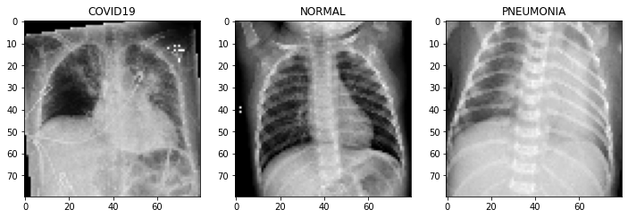

```python
temp = train.next()
img_codes = temp[0]
img_labels = temp[1]
y_classes = [np.argmax(y, axis=None, out=None) for y in img_labels]
indexes = [y_classes.index(x) for x in sorted(set(y_classes))]
plt.figure(figsize=(12,8))
for i in range(len(indexes)):
  plt.subplot(1,3,i+1)
  reshaped_row = img_codes[indexes[i]].reshape(pic_size)
  plt.imshow(reshaped_row, cmap=plt.cm.gray)
  plt.title(tag_names[y_classes[indexes[i]]])
```

## Showing Count of each class

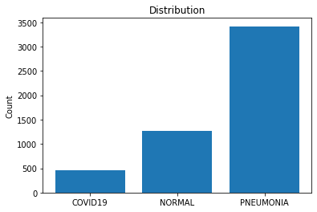

```python
class_list = train.classes
D = dict(Counter(class_list))
plt.bar(range(len(D)), list(D.values()), align='center')
plt.ylabel('Count')
plt.xticks(range(len(D)), tag_names)
plt.title('Distribution')
plt.show()
```

## Part3 and 4:

```python
def adjust_layers(activation_method, class_num):
  layer_input = layers.Input(shape=(80,80,1))
  out = layers.Flatten()(layer_input)
  out = layers.Dense(1024, activation=activation_method)(out)
  out = layers.Dense(2048, activation=activation_method)(out)
  out = layers.Dense(4096, activation=activation_method)(out)
  out = layers.Dense(2048, activation=activation_method)(out)
  out = layers.Dense(1024, activation=activation_method)(out)
  out = layers.Dense(class_num, activation="softmax")(out)
  return (layer_input, out)

def make_model(activation_method, class_num, learning_rate, mom_value, loss_function_name, optimizer_method, epoch_count):
  layer_input, out = adjust_layers(activation_method, class_num)
  prediction_model = models.Model(inputs = layer_input, outputs = out)
  if (optimizer_method == 'SGD'):
    prediction_model.compile(optimizer = optimizers.SGD(learning_rate=learning_rate, momentum=mom_value), loss = loss_function_name,
                          metrics = ['accuracy'])
  elif (optimizer_method == 'Adam'):
    prediction_model.compile(optimizer = optimizers.Adam(learning_rate=0.001), loss = loss_function_name,
                          metrics = ['accuracy'])
  history = prediction_model.fit(train, epochs=epoch_count, validation_data=test)
  return history, prediction_model
```

```python
def draw_plot(history):
  plt.figure(figsize=(15,5))

  plt.subplot(1,2,1)
  plt.plot(history.history['accuracy'])
  plt.plot(history.history['val_accuracy'])
  plt.title('Model accuracy')
  plt.ylabel('accuracy')
  plt.xlabel('epoch')
  plt.legend(['train', 'test'], loc='upper right')

  plt.subplot(1,2,2)
  plt.plot(history.history['loss'])
  plt.plot(history.history['val_loss'])
  plt.title('Model loss')
  plt.ylabel('loss')
  plt.xlabel('epoch')
  plt.legend(['train', 'test'], loc='upper right')
```

## Section1:

## Relu:

Since input data is not normalized, loss value will dramatically increase in short bursts of time and it will cause overflow. A target variable with a large spread of values, in turn, may result in large error gradient values causing weight values to change dramatically, making the learning process unstable. Normalization ensures that the magnitude of the values that a feature assumes are more or less the same. Also, relu funtion will map values larger than zero to themselves so after some round of derivation and multiplication, loss values tend to converge to infinity (represented by nan since they are impossible to be shown as float numbers)

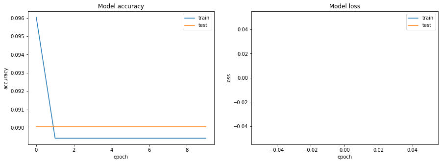

```python
history, prediction_model = make_model("relu", 3, 0.01, 0, "categorical_crossentropy", 'SGD', 10)
test_predictions = prediction_model.predict(test_no_shuffle)
train_predictions = prediction_model.predict(train_no_shuffle)
draw_plot(history)
```

```python
y_true = test.classes
y_pred = np.rint(test_predictions)
print(classification_report(y_true, np.argmax(y_pred, axis=1)))
```

```
              precision    recall  f1-score   support

           0       0.09      1.00      0.17       116
           1       0.00      0.00      0.00       317
           2       0.00      0.00      0.00       855

    accuracy                           0.09      1288
   macro avg       0.03      0.33      0.06      1288
weighted avg       0.01      0.09      0.01      1288
```

```python
x_true = train.classes
x_pred = np.rint(train_predictions)
print(classification_report(x_true, np.argmax(x_pred, axis=1)))
```

```
              precision    recall  f1-score   support

           0       0.09      1.00      0.16       460
           1       0.00      0.00      0.00      1266
           2       0.00      0.00      0.00      3418

    accuracy                           0.09      5144
   macro avg       0.03      0.33      0.05      5144
weighted avg       0.01      0.09      0.01      5144
```

## Section2:

## Tanh:

Due to the nature of Tanh activation function, values have some sort of ceiling. To be more accurate, this activation method maps input values to a float number from -1 to 1. So we can expect that loss values will not experince and overflow. Please note that this models too has not performed well in total prediction since f1 score for first and second class is 0.

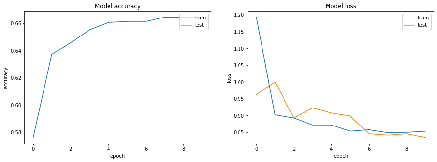

```python
history, prediction_model = make_model("tanh", 3, 0.01, 0, "categorical_crossentropy", 'SGD', 10)
test_predictions = prediction_model.predict(test_no_shuffle)
train_predictions = prediction_model.predict(train_no_shuffle)
draw_plot(history)
```

```python
y_true = test.classes
y_pred = np.rint(test_predictions)
print(classification_report(y_true, np.argmax(y_pred, axis=1)))
```

```
              precision    recall  f1-score   support

           0       0.00      0.00      0.00       116
           1       0.00      0.00      0.00       317
           2       0.66      1.00      0.80       855

    accuracy                           0.66      1288
   macro avg       0.22      0.33      0.27      1288
weighted avg       0.44      0.66      0.53      1288
```

```python
x_true = train.classes
x_pred = np.rint(train_predictions)
print(classification_report(x_true, np.argmax(x_pred, axis=1)))
```

```
              precision    recall  f1-score   support

           0       0.00      0.00      0.00       460
           1       0.00      0.00      0.00      1266
           2       0.66      1.00      0.80      3418

    accuracy                           0.66      5144
   macro avg       0.22      0.33      0.27      5144
weighted avg       0.44      0.66      0.53      5144
```

## Section3:

Both models have performed poorly in prediction. Relu has f1 values equal to zero for classes 1 and 2. Tanh has f1 values equal to zero for classes 0 and 1 due to the size of last class. Tanh will no cause loss values to converge to infinity due to it's nature of having outputs in range of (-1,1). On the other hand, Relu will cause overflow in loss values since it's output has no limit. There reason that both models have failed is the lack of normalization. By normalizing data, ensurance will be given that the magnitude of the values that a feature assumes are more or less the same.

# Part5:

```
Found 5144 images belonging to 3 classes.
Found 5144 images belonging to 3 classes.
Found 1288 images belonging to 3 classes.
Found 1288 images belonging to 3 classes.
```

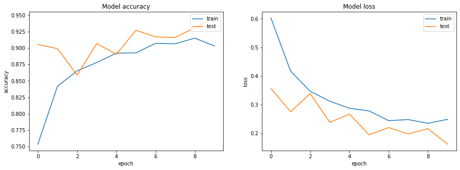

```python
train, test, train_no_shuffle, test_no_shuffle = make_dataset(255)
history, prediction_model = make_model("relu", 3, 0.01, 0, "categorical_crossentropy", 'SGD', 10)
test_predictions = prediction_model.predict(test_no_shuffle)
train_predictions = prediction_model.predict(train_no_shuffle)
draw_plot(history)
```

```python
y_true = test.classes
y_pred = np.rint(test_predictions)
print(classification_report(y_true, np.argmax(y_pred, axis=1)))
```

```
              precision    recall  f1-score   support

           0       0.95      0.84      0.89       116
           1       0.92      0.90      0.91       317
           2       0.95      0.97      0.96       855

    accuracy                           0.94      1288
   macro avg       0.94      0.91      0.92      1288
weighted avg       0.94      0.94      0.94      1288
```

```python
x_true = train.classes
x_pred = np.rint(train_predictions)
print(classification_report(x_true, np.argmax(x_pred, axis=1)))
```

```
              precision    recall  f1-score   support

           0       0.94      0.88      0.90       460
           1       0.91      0.85      0.88      1266
           2       0.94      0.97      0.95      3418

    accuracy                           0.93      5144
   macro avg       0.93      0.90      0.91      5144
weighted avg       0.93      0.93      0.93      5144
```

# Part6:

## Section1:

Momentum is a float hyperparameter that helps SGD to go to relevant sections while also reducing occilation. The way it works is by considering a small part of the update vector from last steps and adding that to the update vector that is currently being used. Without it, SGD can get stuck is local optimas where the surface curve is much more steep in one dimension.

[figure not shown]

## Section2:

### Momentum = 0.5

As we can see the results, by using 0.5 as momentum, there have been much less fluctuation in plots. Accuracy and loss tend to converge smoother to their optimal values along the iterations.

```
Found 5144 images belonging to 3 classes.
Found 5144 images belonging to 3 classes.
Found 1288 images belonging to 3 classes.
Found 1288 images belonging to 3 classes.
```

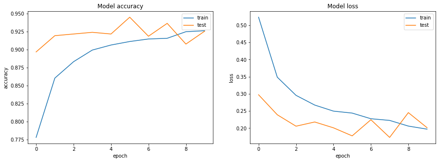

```python
train, test, train_no_shuffle, test_no_shuffle = make_dataset(255)
history, prediction_model = make_model("relu", 3, 0.01, 0.5, "categorical_crossentropy", 'SGD', 10)
test_predictions = prediction_model.predict(test_no_shuffle)
train_predictions = prediction_model.predict(train_no_shuffle)
draw_plot(history)
```

```python
y_true = test.classes
y_pred = np.rint(test_predictions)
print(classification_report(y_true, np.argmax(y_pred, axis=1)))
```

```
              precision    recall  f1-score   support

           0       1.00      0.71      0.83       116
           1       0.93      0.84      0.89       317
           2       0.92      0.99      0.95       855

    accuracy                           0.93      1288
   macro avg       0.95      0.85      0.89      1288
weighted avg       0.93      0.93      0.92      1288
```

```python
x_true = train.classes
x_pred = np.rint(train_predictions)
print(classification_report(x_true, np.argmax(x_pred, axis=1)))
```

```
              precision    recall  f1-score   support

           0       0.99      0.77      0.87       460
           1       0.94      0.82      0.87      1266
           2       0.92      0.99      0.95      3418

    accuracy                           0.93      5144
   macro avg       0.95      0.86      0.90      5144
weighted avg       0.93      0.93      0.92      5144
```

### Momentum = 0.9

```
Found 5144 images belonging to 3 classes.
Found 5144 images belonging to 3 classes.
Found 1288 images belonging to 3 classes.
Found 1288 images belonging to 3 classes.
```

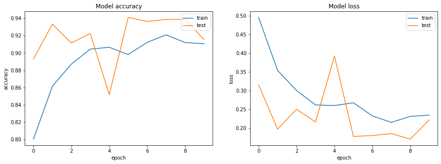

```python
train, test, train_no_shuffle, test_no_shuffle = make_dataset(255)
history, prediction_model = make_model("relu", 3, 0.01, 0.9, "categorical_crossentropy", 'SGD', 10)
test_predictions = prediction_model.predict(test_no_shuffle)
train_predictions = prediction_model.predict(train_no_shuffle)
draw_plot(history)
```

```python
y_true = test.classes
y_pred = np.rint(test_predictions)
print(classification_report(y_true, np.argmax(y_pred, axis=1)))
```

```
              precision    recall  f1-score   support

           0       0.97      0.72      0.83       116
           1       0.82      0.95      0.88       317
           2       0.96      0.93      0.94       855

    accuracy                           0.92      1288
   macro avg       0.91      0.87      0.88      1288
weighted avg       0.92      0.92      0.92      1288
```

```python
x_true = train.classes
x_pred = np.rint(train_predictions)
print(classification_report(x_true, np.argmax(x_pred, axis=1)))
```

```
              precision    recall  f1-score   support

           0       0.97      0.77      0.86       460
           1       0.80      0.94      0.87      1266
           2       0.96      0.92      0.94      3418

    accuracy                           0.91      5144
   macro avg       0.91      0.88      0.89      5144
weighted avg       0.92      0.91      0.91      5144
```

### Momentum = 0.99

```
Found 5144 images belonging to 3 classes.
Found 5144 images belonging to 3 classes.
Found 1288 images belonging to 3 classes.
Found 1288 images belonging to 3 classes.
```

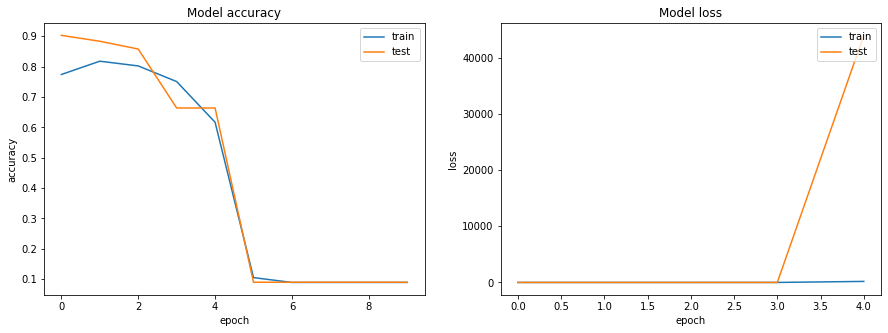

```python
train, test, train_no_shuffle, test_no_shuffle = make_dataset(255)
history, prediction_model = make_model("relu", 3, 0.01, 0.99, "categorical_crossentropy", 'SGD', 10)
test_predictions = prediction_model.predict(test_no_shuffle)
train_predictions = prediction_model.predict(train_no_shuffle)
draw_plot(history)
```

```python
y_true = test.classes
y_pred = np.rint(test_predictions)
print(classification_report(y_true, np.argmax(y_pred, axis=1)))
```

```
              precision    recall  f1-score   support

           0       0.09      1.00      0.17       116
           1       0.00      0.00      0.00       317
           2       0.00      0.00      0.00       855

    accuracy                           0.09      1288
   macro avg       0.03      0.33      0.06      1288
weighted avg       0.01      0.09      0.01      1288
```

```python
x_true = train.classes
x_pred = np.rint(train_predictions)
print(classification_report(x_true, np.argmax(x_pred, axis=1)))
```

```
              precision    recall  f1-score   support

           0       0.09      1.00      0.16       460
           1       0.00      0.00      0.00      1266
           2       0.00      0.00      0.00      3418

    accuracy                           0.09      5144
   macro avg       0.03      0.33      0.05      5144
weighted avg       0.01      0.09      0.01      5144
```

## Section4:

Adam is actually a combination of two stochastic gradient descent algorithms. First one being **Adaptive Gradient Algorithm** and second one being **Root Mean Square Propagation** . It stores last gradients and uses them to optimize current run. Like most neural network functions, recent gradients have a greater impact than older ones. As we can see below, there is not much difference between adams results and results from **Part5** . However, it is clear that by usign adam, loss and accuracy have both reached their optimum points faster than in the case of SGD.

```
Found 5144 images belonging to 3 classes.
Found 5144 images belonging to 3 classes.
Found 1288 images belonging to 3 classes.
Found 1288 images belonging to 3 classes.
```

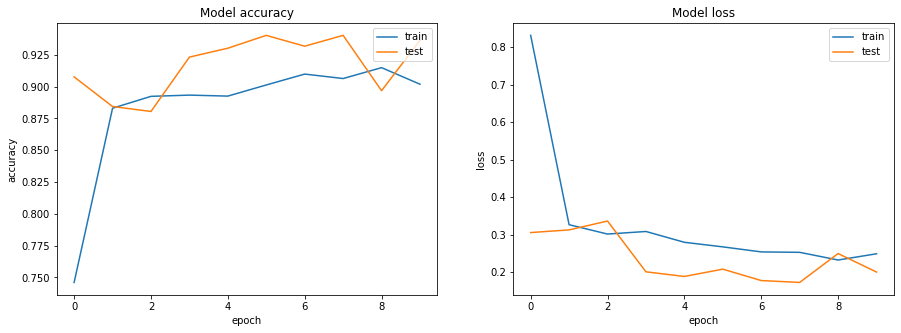

```python
train, test, train_no_shuffle, test_no_shuffle = make_dataset(255)
history, prediction_model = make_model("relu", 3, 0.01, 0, "categorical_crossentropy", 'Adam', 10)
test_predictions = prediction_model.predict(test_no_shuffle)
train_predictions = prediction_model.predict(train_no_shuffle)
draw_plot(history)
```

```python
y_true = test.classes
y_pred = np.rint(test_predictions)
print(classification_report(y_true, np.argmax(y_pred, axis=1)))
```

```
              precision    recall  f1-score   support

           0       0.92      0.86      0.89       116
           1       0.88      0.91      0.90       317
           2       0.96      0.95      0.96       855

    accuracy                           0.94      1288
   macro avg       0.92      0.91      0.91      1288
weighted avg       0.94      0.94      0.94      1288
```

```python
x_true = train.classes
x_pred = np.rint(train_predictions)
print(classification_report(x_true, np.argmax(x_pred, axis=1)))
```

```
              precision    recall  f1-score   support

           0       0.92      0.87      0.89       460
           1       0.88      0.89      0.89      1266
           2       0.95      0.95      0.95      3418

    accuracy                           0.93      5144
   macro avg       0.92      0.90      0.91      5144
weighted avg       0.93      0.93      0.93      5144
```

# Part7:

## Section1:

```
Found 5144 images belonging to 3 classes.
Found 5144 images belonging to 3 classes.
Found 1288 images belonging to 3 classes.
Found 1288 images belonging to 3 classes.
```

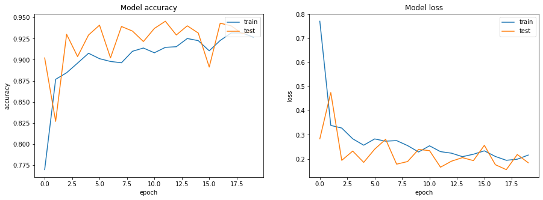

```python
train, test, train_no_shuffle, test_no_shuffle = make_dataset(255)
history, prediction_model = make_model("relu", 3, 0.01, 0, "categorical_crossentropy", 'Adam', 20)
test_predictions = prediction_model.predict(test_no_shuffle)
train_predictions = prediction_model.predict(train_no_shuffle)
draw_plot(history)
```

```python
y_true = test.classes
y_pred = np.rint(test_predictions)
print(classification_report(y_true, np.argmax(y_pred, axis=1)))
```

```
              precision    recall  f1-score   support

           0       0.89      0.88      0.89       116
           1       0.87      0.93      0.90       317
           2       0.97      0.94      0.95       855

    accuracy                           0.93      1288
   macro avg       0.91      0.92      0.91      1288
weighted avg       0.93      0.93      0.93      1288
```

```python
x_true = train.classes
x_pred = np.rint(train_predictions)
print(classification_report(x_true, np.argmax(x_pred, axis=1)))
```

```
              precision    recall  f1-score   support

           0       0.90      0.89      0.89       460
           1       0.87      0.93      0.90      1266
           2       0.97      0.95      0.96      3418

    accuracy                           0.94      5144
   macro avg       0.91      0.92      0.92      5144
weighted avg       0.94      0.94      0.94      5144
```

## Section2:

Training a neural network involves optimizing a large set of parameters which are heavily interdependent. Because of this, it can take a lot of labelled training examples before the network starts playing around an area which is accurate enough. Especially when we are using gradient descent. Model typicaly needs large amounts of data to process. In normal life, there are many situations where there's insufficient amount of data and as a result, more iterations are required to converge to an acceptable optimum (more iterations mean more epochs). Also, gradient descent is a step-by-step algorithm which improves over iterations(by learing rate) so it is clear that a number of iterations can give a better guarantee that just one run.

On the other hand, when there's a good amount of training data, there's ususally less need for multiple epochs since the very essential requirement is already present. (Large amounts of data to process and make model)

## Section3:

There is a downside to increasing number of epochs. It can casue model to be overfitted to train data. As a result, it will perform accurately on train dateset but poorly on test. There are two main approaches to mitigate such impact. **First:** Increase size of dataset so that minimum amount of epochs can be used to reach a optimal point. This act can be done by either gathering more data or tangling with current dataset to produce unseen data. **Second:** Consider output of the best performing epoch, whether it's the last one or not. This method is called early stopping.

# Part8:

## Section1:

Loss values are all within a similiar range (train and test). Also there's no change in accuracy so there's no learning here. By examining F1 score for test and train we can see that all samples are tagged "2" and no samples are predicted to be in classes "0" or "1" which is obviously a poor performance.

```
Found 5144 images belonging to 3 classes.
Found 5144 images belonging to 3 classes.
Found 1288 images belonging to 3 classes.
Found 1288 images belonging to 3 classes.
```

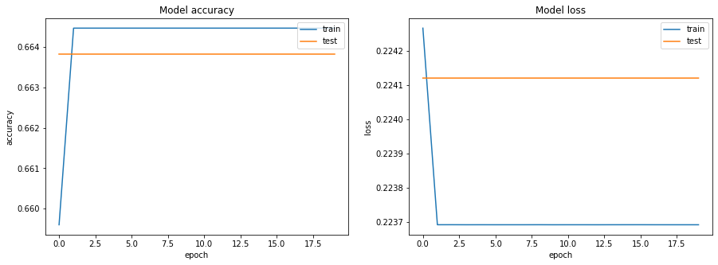

```python
train, test, train_no_shuffle, test_no_shuffle = make_dataset(255)
history, prediction_model = make_model("relu", 3, 0.01, 0, "mse", 'Adam', 20)
test_predictions = prediction_model.predict(test_no_shuffle)
train_predictions = prediction_model.predict(train_no_shuffle)
draw_plot(history)
```

```python
y_true = test.classes
y_pred = np.rint(test_predictions)
print(classification_report(y_true, np.argmax(y_pred, axis=1)))
```

```
              precision    recall  f1-score   support

           0       0.00      0.00      0.00       116
           1       0.00      0.00      0.00       317
           2       0.66      1.00      0.80       855

    accuracy                           0.66      1288
   macro avg       0.22      0.33      0.27      1288
weighted avg       0.44      0.66      0.53      1288
```

```python
x_true = train.classes
x_pred = np.rint(train_predictions)
print(classification_report(x_true, np.argmax(x_pred, axis=1)))
```

```
              precision    recall  f1-score   support

           0       0.00      0.00      0.00       460
           1       0.00      0.00      0.00      1266
           2       0.66      1.00      0.80      3418

    accuracy                           0.66      5144
   macro avg       0.22      0.33      0.27      5144
weighted avg       0.44      0.66      0.53      5144
```

## Section2:

MSE is mostly used in regression models and will perfom poorly when used in classification problems. There are two main reasons for this phenomenon. First one is that in MSE, it is presupposed that input data's distribution is normal when it reality it might not be! Here we have three categories. (If we had two, it would be called Bernoulli distribution) Second one is that if a binary classification model is trained with MSE Cost function, it is not guaranteed to minimize the Cost function. Main reason is that by using MSE there will be a expectation that values will be in range of (-inf, +inf) while model outputs are actually probabilities ranging from 0 to 1 and MSE will be severly limited.

[figure not shown]

# Part9:

## Section2:

When using kernel regulizer, we can see that train and test accuracy have become much more similiar along multiple epochs. By taking a closer look to classification_report,F1 scores are a bit better than before By applying a penalty to weights, those values are kept within a range . This is useful since weights tend to change drastically during last rounds in order to fit model to train data. Also, sum of these penalties are then added to the loss function that network uses. Here we have used L2 regulizer. The L2 regularization penalty is computed as: loss = l2 * reduce_sum(square(x))

```python
def adjust_layers(activation_method, class_num):
  layer_input = layers.Input(shape=(80,80,1))
  out = layers.Flatten()(layer_input)
  out = layers.Dense(1024, activation=activation_method, kernel_regularizer=regularizers.L2(0.0001))(out)
  out = layers.Dense(2048, activation=activation_method, kernel_regularizer=regularizers.L2(0.0001))(out)
  out = layers.Dense(4096, activation=activation_method, kernel_regularizer=regularizers.L2(0.0001))(out)
  out = layers.Dense(2048, activation=activation_method, kernel_regularizer=regularizers.L2(0.0001))(out)
  out = layers.Dense(1024, activation=activation_method, kernel_regularizer=regularizers.L2(0.0001))(out)
  out = layers.Dense(class_num, activation="softmax", kernel_regularizer=regularizers.L2(0.0001))(out)
  return (layer_input, out)

def make_model(activation_method, class_num, learning_rate, mom_value, loss_function_name, optimizer_method, epoch_count):
  layer_input, out = adjust_layers(activation_method, class_num)
  prediction_model = models.Model(inputs = layer_input, outputs = out)
  if (optimizer_method == 'SGD'):
    prediction_model.compile(optimizer = optimizers.SGD(learning_rate=learning_rate, momentum=mom_value), loss = loss_function_name,
                          metrics = ['accuracy'])
  elif (optimizer_method == 'Adam'):
    prediction_model.compile(optimizer = optimizers.Adam(learning_rate=0.001), loss = loss_function_name,
                          metrics = ['accuracy'])
  history = prediction_model.fit(train, epochs=epoch_count, validation_data=test)
  return history, prediction_model
```

```
Found 5144 images belonging to 3 classes.
Found 5144 images belonging to 3 classes.
Found 1288 images belonging to 3 classes.
Found 1288 images belonging to 3 classes.
```

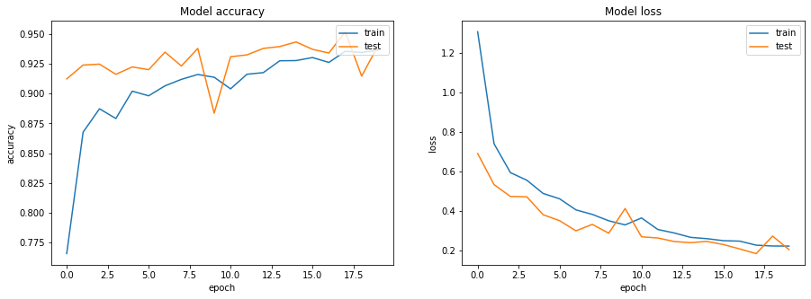

```python
train, test, train_no_shuffle, test_no_shuffle = make_dataset(255)
history, prediction_model = make_model("relu", 3, 0.01, 0, "categorical_crossentropy", 'Adam', 20)
test_predictions = prediction_model.predict(test_no_shuffle)
train_predictions = prediction_model.predict(train_no_shuffle)
draw_plot(history)
```

```python
y_true = test.classes
y_pred = np.rint(test_predictions)
print(classification_report(y_true, np.argmax(y_pred, axis=1)))
```

```
              precision    recall  f1-score   support

           0       0.95      0.90      0.92       116
           1       0.95      0.85      0.90       317
           2       0.94      0.98      0.96       855

    accuracy                           0.94      1288
   macro avg       0.94      0.91      0.92      1288
weighted avg       0.94      0.94      0.94      1288
```

```python
x_true = train.classes
x_pred = np.rint(train_predictions)
print(classification_report(x_true, np.argmax(x_pred, axis=1)))
```

```
              precision    recall  f1-score   support

           0       0.93      0.93      0.93       460
           1       0.97      0.81      0.88      1266
           2       0.93      0.99      0.96      3418

    accuracy                           0.94      5144
   macro avg       0.94      0.91      0.92      5144
weighted avg       0.94      0.94      0.94      5144
```

## Section3:

By using dropout, During training, some number of layer outputs are randomly ignored or “dropped out.” This measn removing it from the network. A great impact is the speed up that we will recieve due to using this function. Also, it has the capacity of thinning the network during training so as a result, there has been minor changes in accuracy and loss of train dataset (detriment changes). But overall, F1 scores have not changed much compared to last runs. The underlying mechanism is that a new hyperparameter is introduced that specifies the probability at which outputs of the layer are dropped out, or inversely, the probability at which outputs of the layer are retained.

```python
def adjust_layers(activation_method, class_num):
  layer_input = layers.Input(shape=(80,80,1))
  out = layers.Flatten()(layer_input)
  out = layers.Dropout(0.1)(out)
  out = layers.Dense(1024, activation=activation_method)(out)
  out = layers.Dropout(0.1)(out)
  out = layers.Dense(2048, activation=activation_method)(out)
  out = layers.Dropout(0.1)(out)
  out = layers.Dense(4096, activation=activation_method)(out)
  out = layers.Dropout(0.1)(out)
  out = layers.Dense(2048, activation=activation_method)(out)
  out = layers.Dropout(0.1)(out)
  out = layers.Dense(1024, activation=activation_method)(out)
  out = layers.Dropout(0.1)(out)
  out = layers.Dense(class_num, activation="softmax")(out)
  return (layer_input, out)

def make_model(activation_method, class_num, learning_rate, mom_value, loss_function_name, optimizer_method, epoch_count):
  layer_input, out = adjust_layers(activation_method, class_num)
  prediction_model = models.Model(inputs = layer_input, outputs = out)
  if (optimizer_method == 'SGD'):
    prediction_model.compile(optimizer = optimizers.SGD(learning_rate=learning_rate, momentum=mom_value), loss = loss_function_name,
                          metrics = ['accuracy'])
  elif (optimizer_method == 'Adam'):
    prediction_model.compile(optimizer = optimizers.Adam(learning_rate=0.001), loss = loss_function_name,
                          metrics = ['accuracy'])
  history = prediction_model.fit(train, epochs=epoch_count, validation_data=test)
  return history, prediction_model
```

```
Found 5144 images belonging to 3 classes.
Found 5144 images belonging to 3 classes.
Found 1288 images belonging to 3 classes.
Found 1288 images belonging to 3 classes.
```

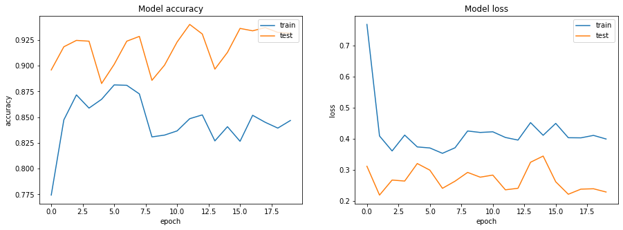

```python
train, test, train_no_shuffle, test_no_shuffle = make_dataset(255)
history, prediction_model = make_model("relu", 3, 0.01, 0, "categorical_crossentropy", 'Adam', 20)
test_predictions = prediction_model.predict(test_no_shuffle)
train_predictions = prediction_model.predict(train_no_shuffle)
draw_plot(history)
```

```python
y_true = test.classes
y_pred = np.rint(test_predictions)
print(classification_report(y_true, np.argmax(y_pred, axis=1)))
```

```
              precision    recall  f1-score   support

           0       0.82      0.97      0.89       116
           1       0.92      0.87      0.89       317
           2       0.95      0.95      0.95       855

    accuracy                           0.93      1288
   macro avg       0.90      0.93      0.91      1288
weighted avg       0.93      0.93      0.93      1288
```

```python
x_true = train.classes
x_pred = np.rint(train_predictions)
print(classification_report(x_true, np.argmax(x_pred, axis=1)))
```

```
              precision    recall  f1-score   support

           0       0.79      0.93      0.86       460
           1       0.91      0.84      0.87      1266
           2       0.94      0.95      0.95      3418

    accuracy                           0.92      5144
   macro avg       0.88      0.91      0.89      5144
weighted avg       0.92      0.92      0.92      5144
```